# Vermilion Rockfish

*Sebastes miniatus*

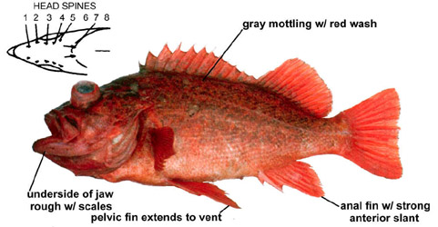

**Body color:** Dark red, mottled w/ gray on back and sides; fins red.

**Peritoneum color:** light **Shape between eyes:** convex

**Counts:** D:XIII,13-15, Ar:6-8, P1:16-18, GR:35-43, LLp:40-48, LLs:45-48, V:26-27

**Occurence:** Gulf of Alaska - Baja California

**Depth:** 183-274 meters **Size:** 76 cm **Species code:** 30350

**Similar species:**

- *Canary rockfish* - body orange w/ olive-gray, fins orange; underside of lower jaw smooth w/ embedded scales; gillrakers 41-45 (35-43 in Vermilion RF); lateral line highlighted in gray
- *Yelloweye rockfish* - head spines rugose; body orange-red to orange-yellow w/out olive-gray mottling; lateral line highlighted in gray; anal-fin margin rounded
- *Rougheye rockfish, Shortraker rockfish, and Blackgill rockfish* - head spine count differs; anal-fin margin perpendicular; 0-8 spines below eye

Back to Group

**Corrections:** If you see mistakes or want to suggest changes, please create an [issue](https://github.com/zoyafuso-NOAA/RACE_Survey_App/issues) on the source repository or

*reach out to Liz Dawson (Liz.Dawson AT noaa.gov).*